# Visualization of `quanTIseq` deconvolution results

SJ Spielman (ALSF CCDL) and Jo Lynne Rokita (D3b)

2022

#### Files and paths

```r
library(tidyverse)
library(ggpubr)
# set seed
set.seed(2022)

# Establish base dir
root_dir <- rprojroot::find_root(rprojroot::has_dir(".git"))

# Data directory
data_dir <- file.path(root_dir, "data")

# Analysis directory
analysis_dir <- file.path(root_dir, "analyses", "immune-deconv")

# Palettes
palette_dir <- file.path(root_dir, "figures", "palettes")

# Declare output directory
output_dir <- file.path(analysis_dir, "plots")
if (!dir.exists(output_dir)) {
  dir.create(output_dir)
}

# Define input files
hist_file <- file.path(data_dir, "pbta-histologies.tsv")
palette_file <- file.path(palette_dir, "broad_histology_cancer_group_palette.tsv")
quantiseq_file <- file.path(analysis_dir, "results", "quantiseq_deconv-output.rds")
polya_file <- file.path(data_dir, "pbta-gene-expression-rsem-fpkm-collapsed.polya.rds")
stranded_file <- file.path(data_dir, "pbta-gene-expression-rsem-fpkm-collapsed.stranded.rds")


# Define output files
cg_celltypes_plot_file <- file.path(output_dir, "cell_types-cancer_groups.pdf")
subtypes_celltypes_plot_file <- file.path(output_dir, "cell_types-molecular_subtypes.pdf")
pdl1_distributions_plot_file  <- file.path(output_dir, "PDL1_expression_distributions.pdf")
cd274_mb_plot_file <- file.path(output_dir, "cd274_expression_mb_subtypes.pdf")
cd8_cd4_ratio_plot_file <- file.path(output_dir, "cd8_cd4_ratio.pdf")
```

Read in data files:

```r
# Read in clinical data and palette file
histologies_df <- read_tsv(hist_file, guess_max = 10000)
palette_df <- readr::read_tsv(palette_file)
# Read in analysis data
quantiseq <- read_rds(quantiseq_file)
polya <- read_rds(polya_file)
stranded <- read_rds(stranded_file)
```

The following chunk prepares data for visualization: + Prepare histology and palette for *all* samples. Both polya and stranded libraries were used in deconvolution. + Define cancer groups of interest to plot + Subset data to those cancer groups of interest where molecular subtypes have n>=3

```r
#### Prepare palette/histology data data
palette_mapping_df <- histologies_df %>%
  # RNA-Seq samples only, *****BOTH****** polya and stranded
  filter(experimental_strategy == "RNA-Seq") %>%
  # Identifiers
  select(Kids_First_Biospecimen_ID,
         Kids_First_Participant_ID,
         sample_id,
         broad_histology,
         cancer_group,
         molecular_subtype) %>%
  # Add in hex codes & display grouping
  left_join(palette_df,
            by = c("broad_histology", "cancer_group")) %>%
  select(Kids_First_Biospecimen_ID,
         contains("broad_histology"),
         contains("cancer_group"),
         molecular_subtype)

#### Determine the of groups we want to visualize from those with N>=15, excluding Other
cancer_groups_of_interest <- palette_mapping_df %>%
    filter(cancer_group_display != "Other", !is.na(cancer_group_display)) %>%
  group_by(cancer_group_display) %>%
  tally() %>%
  arrange(-n) %>%
  filter(n > 15) %>%
  pull(cancer_group_display)

#### Array of groups we want to visualize (chose 12/14 above)
# Exclude other HGG/LGG since the patterns are similar to pilocytic/DMG
cancer_groups_of_interest <- c("Pilocytic astrocytoma",
                               "Diffuse midline glioma",
                               "Craniopharyngioma",
                               "Ganglioglioma",
                               "Ependymoma",
                               "Medulloblastoma",
                               "Schwannoma",
                               "Neurofibroma Plexiform",
                               "Other embryonal tumor",
                               "Atypical Teratoid Rhabdoid Tumor",
                               "Meningioma",
                               "Dysembryoplastic neuroepithelial tumor")

#### Prepare quanTIseq data --> `quantiseq_subset`
# spread and create cd8/cd4 ratio
quantiseq_spread <- quantiseq %>%
  # get a column for each cell type
  spread(cell_type, score) %>%
  mutate(cd8_cd4_ratio = `T cell CD8+` / `T cell CD4+ (non-regulatory)`)

quantiseq_gather <- quantiseq_spread %>%
  gather(cell_type, score, -c(sample, library, method))

# First, find the molecular subtypes in the of interest cancer groups AND excluding unclassified, with >=3 samples
subtypes_of_interest <- palette_mapping_df %>%
  filter(cancer_group_display %in% cancer_groups_of_interest,
         !(str_detect(molecular_subtype, "To be classified"))) %>%
  count(molecular_subtype) %>%
  filter(n >= 3) %>%
  pull(molecular_subtype)


# Now, filter to relevant samples and remove uncharacterized fractions
quantiseq_subset <- quantiseq_gather %>%
  left_join(palette_mapping_df, by = c("sample" = "Kids_First_Biospecimen_ID")) %>%
  filter(molecular_subtype %in% subtypes_of_interest,
         cell_type != "uncharacterized cell") %>%
  # Change loss --> loss here so inherited by all
  mutate(molecular_subtype = ifelse(molecular_subtype == "DMG, H3 K28, TP53 loss",
                                           "DMG, H3 K28, TP53 lost",
                                           molecular_subtype))


#### Prepare expression data to explore PDL1 aka CD274 ---> `expression_pdl1`

# Combine polya and stranded to get expression for pdl1, while keeping a library annotation
polya_expression <- polya %>%
  rownames_to_column("gene") %>%
  filter(gene == "CD274") %>%
  gather(-gene, key = sample, value = expression) %>%
  mutate(library = "polya")

expression_pdl1 <- stranded %>%
  rownames_to_column("gene") %>%
  filter(gene == "CD274") %>%
  gather(-gene, key = sample, value = expression) %>%
  mutate(library = "stranded") %>%
  bind_rows(polya_expression) %>%
  as_tibble() %>%
  mutate(log2_expression = log(expression +1, 2)) %>%
  select(-expression)
```

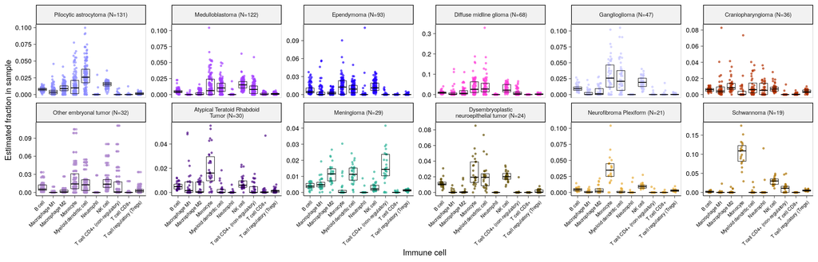

```r
# Faceted plot of cancer groups, cell types. Jitter points are colored by cancer group.
# Now, filter to relevant samples and remove uncharacterized fractions
quantiseq_subset_cg <- quantiseq_gather %>%
  filter(cell_type != "uncharacterized cell" & cell_type != "cd8_cd4_ratio") %>%
  left_join(palette_mapping_df, by = c("sample" = "Kids_First_Biospecimen_ID")) %>%
  filter(cancer_group_display %in% cancer_groups_of_interest)

# We need to create a new scheme for labeling that shows wrapped cancer groups with `(n=X)`
quantiseq_subset_cg <- quantiseq_subset_cg %>%
  dplyr::count(cancer_group_display, cell_type) %>%
  dplyr::select(-cell_type) %>%
  dplyr::distinct() %>%
  dplyr::inner_join(
      dplyr::select(palette_df, dplyr::contains("cancer_group"))
  ) %>%
  dplyr::select(cancer_group_display, n, cancer_group_hex) %>%
  # Create wrapped with (n=X) factor column for cancer groups
  dplyr::mutate(cancer_group_display_n = stringr::str_wrap(glue::glue("{cancer_group_display} (N={n})"), 30),
                cancer_group_display_n = forcats::fct_reorder(cancer_group_display_n, n, .desc=T)) %>%
  dplyr::inner_join(quantiseq_subset_cg)
# plot by cancer group
cg_plot <- quantiseq_subset_cg %>%
  ggplot2::ggplot() +
  aes(x = cell_type, y = score, color = cancer_group_hex) +
  geom_jitter(width = 0.15, size = 0.7, alpha = 0.6) +
  ggplot2::geom_boxplot(outlier.size = 0,
                        size = 0.25,
                        color = "black",
                        alpha = 0,
                        # remove whiskers
                        coef = 0) +
  ggplot2::facet_wrap(~cancer_group_display_n, nrow = 2, scales = "free_y") +
  ggplot2::scale_color_identity() +
  ggplot2::labs(
    x = "Immune cell",
    y = "Estimated fraction in sample"
  ) +
  ggpubr::theme_pubr() +
  cowplot::panel_border() +
  ggplot2::theme(
    axis.text.x = ggplot2::element_text(size = 6, angle = 45, hjust = 1),
    axis.text.y = ggplot2::element_text(size = 8),
    axis.title = ggplot2::element_text(size = 10),
    strip.text = ggplot2::element_text(size = 7),
    axis.line = ggplot2::element_line(size = ggplot2::rel(0.5)),
    axis.ticks = ggplot2::element_line(size = ggplot2::rel(0.5)),
    legend.position = "none"
  )

cg_plot
```

```r
ggsave(cg_celltypes_plot_file, cg_plot, width = 11, height = 3.5, useDingbats=FALSE)
```

### Visualize fraction distributions across cell types and molecular subtypes

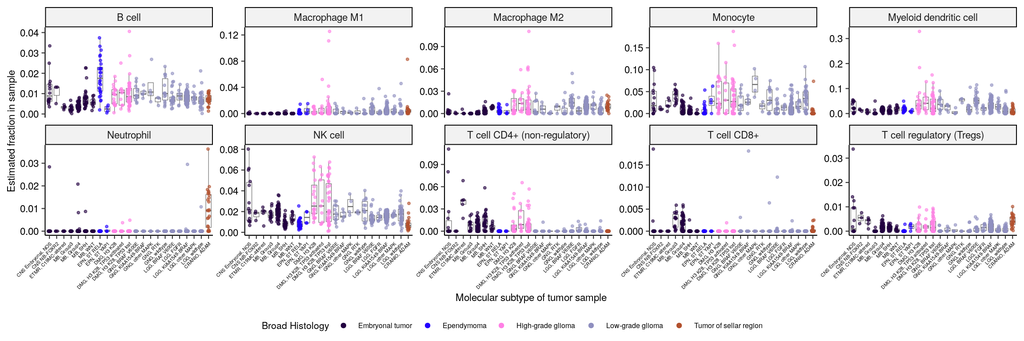

```r
# First, remove cd8_cd4_ratio
quantiseq_no_ratio <- quantiseq_subset %>%
  filter(cell_type != "cd8_cd4_ratio")

# add an ordering to molecular subtypes based on broad_histology_display labels
quantiseq_no_ratio <- quantiseq_no_ratio %>%
  select(broad_histology_display, molecular_subtype) %>%
  unique() %>%
  arrange(broad_histology_display, molecular_subtype) %>%
  mutate(mol_subtype_order = 1:n()) %>%
  #join back to df
  inner_join(quantiseq_no_ratio, by = c("broad_histology_display", "molecular_subtype")) %>%
  dplyr::mutate(molecular_subtype = forcats::fct_reorder(molecular_subtype, mol_subtype_order))

# Faceted plot of subtypes, cell types. Jitter points are colored by underlying cancer group.
subtypes_celltypes_plot <- ggplot(quantiseq_no_ratio) +
  aes(x = molecular_subtype, y = score) +
  geom_boxplot(outlier.shape = NA, color = "grey40", size = 0.2) +
  geom_jitter(width = 0.15, size = 0.75, alpha = 0.6, aes(color = broad_histology_hex)) +
  # change to ncol if we want this *Wide*
  facet_wrap(~cell_type, ncol = 5, scales = "free_y") +
  scale_color_identity() +
  labs(
    x = "Molecular subtype of tumor sample",
    y = "Estimated fraction in sample"
  ) +
  ggpubr::theme_pubr() +
  theme(axis.text.x = element_text(angle = 45, hjust = 1, size = 4),
        axis.title = element_text(size = rel(0.7)),
        axis.text.y = element_text(size = rel(0.7)),
        strip.text = element_text(size = rel(0.7)),
        axis.line = element_line(size = rel(0.7)),
        axis.ticks = element_line(size = rel(0.7)))

# Add legend
cg_color_df <- quantiseq_no_ratio %>%
  select(broad_histology_hex, broad_histology) %>%
  distinct()

cg_color_list <- cg_color_df$broad_histology_hex
names(cg_color_list) <- cg_color_df$broad_histology_display
legend_plot <- ggplot(quantiseq_no_ratio) +
  aes(x = score, y = score, color = broad_histology_display) +
  geom_point() +
  scale_color_manual(name = "Broad Histology", values = cg_color_list) +
  theme_pubr() +
  # Need to make text very small
  theme(
    legend.text = element_text(size = 6),
    legend.title = element_text(size = 8)
  )

legend_panel <- cowplot::get_legend(legend_plot)

full_plot <- cowplot::plot_grid(subtypes_celltypes_plot, legend_panel,
                                nrow = 2,
                                rel_heights = c(1, 0.1))

full_plot
```

```r
ggsave(subtypes_celltypes_plot_file, full_plot, width = 11, height = 3.5, useDingbats=FALSE)
```

### Visualize PDL1 (CD274) expression

In [this](https://www.tandfonline.com/doi/full/10.1080/2162402X.2018.1462430) reference, high levels of both CD8+ and PDL1 can mean good candidate for immunotherapy, and high levels of PDL1 with low levels of CD8+ have been associated with poor prognosis.

First, we explore the relationship between variables with a scatterplot. Because there is very little variation in CD8+, this is not terribly informative.

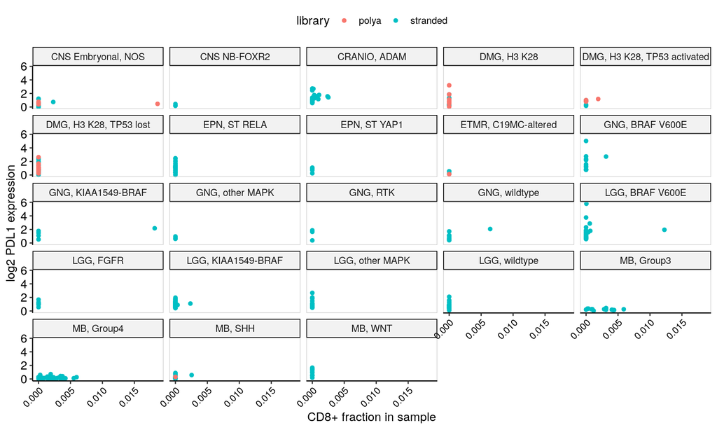

```r
# Merge and subset data to get log2 expression of PDL1 and CD8 fractions
pdl1_cd8 <- expression_pdl1 %>%
  inner_join(quantiseq_subset) %>%
  select(log2_expression, cell_type, library, score, molecular_subtype, cancer_group_display, cancer_group_hex) %>%
  filter(cell_type == "T cell CD8+",
         cancer_group_display != "Other")
# scatterplot of CD8 fractions and PDL1 expression.
ggplot(pdl1_cd8) +
  aes(x = score, y = log2_expression, color = library) +
  geom_jitter() +
  facet_wrap(~molecular_subtype, nrow = 5) +
  labs(x = "CD8+ fraction in sample", y = "log2 PDL1 expression") +
  ggpubr::theme_pubr() +
  theme(axis.text.x = element_text(hjust = 1,
                                   size = rel(0.8),
                                   angle = 45)) +
  cowplot::panel_border()
```

Instead, let’s explore the PDL1 distributions specifically and export this figure:

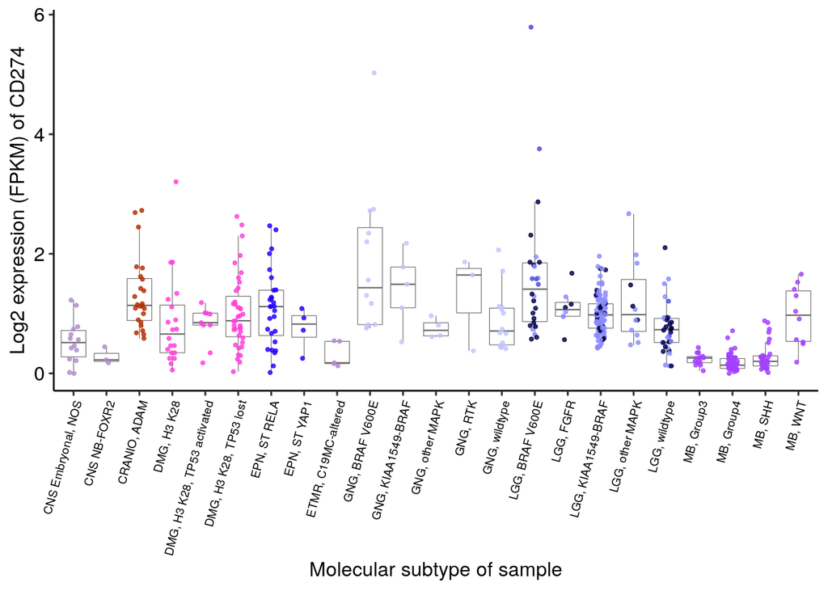

```r
# distributions of PDL1 expression
pdl1_distributions_plot <- ggplot(pdl1_cd8) +
  #aes(x = fct_reorder(molecular_subtype,log2_expression, .desc=T),
  aes(x = molecular_subtype,
      y = log2_expression) +
  # remove outliers
  geom_boxplot(outlier.shape = NA, color = "grey40", size = 0.2) +
  geom_jitter(width = 0.15, size = 0.75, alpha = 0.8, aes(color = cancer_group_hex)) +
  #facet_wrap(~cancer_group_display, nrow = 2, scales = "free") +
  scale_color_identity() +
  labs(x = "Molecular subtype of sample",
       y = "Log2 expression (FPKM) of CD274") +
  ggpubr::theme_pubr() +
  theme(axis.text.x = element_text(hjust = 1,
                                   size = rel(0.6),
                                   angle = 75))

pdl1_distributions_plot
```

```r
ggsave(pdl1_distributions_plot_file, pdl1_distributions_plot, width = 7, height = 5, useDingbats=FALSE)
```

Visualize MB only, since that was the only significant result from the survival analyses

```r
# This chunk should NOT run in CI.
if (!(params$is_ci == 1)) {

# select only mb samples
pdl1_cd8_mb <- pdl1_cd8 %>%
  filter(cancer_group_display == "Medulloblastoma")


# Count group sizes to use in x-axis labels. Use this data frame going forward
df_counts <- pdl1_cd8_mb %>%
  group_by(molecular_subtype) %>%
  mutate(subtype_count = n()) %>%
  ungroup() %>%
  mutate(molecular_subtype = glue::glue("{molecular_subtype}\n(N = {subtype_count})"))

wilcox_df <- ggpubr::compare_means(log2_expression ~ molecular_subtype,
                             data = df_counts,
                             method = "wilcox.test")
wilcox_df

# Add p-values
wilcox_df <- wilcox_df %>%
 mutate(y.position = c(0.8,
                       NA,
                       1.8,
                       1.0,
                       2.0,
                       2.2))

# distributions of PDL1 expression
cd274_plot_mb <- ggplot(df_counts) +
  aes(x = molecular_subtype,
      y = log2_expression) +
  # remove outliers
  geom_boxplot(outlier.shape = NA, color = "grey40", size = 0.2) +
  geom_jitter(width = 0.15, size = 1.4, alpha = 0.5, aes(color = "black")) +
  stat_pvalue_manual(wilcox_df, label = "p = {p.adj}")+
  scale_color_identity() +
  labs(x = "Molecular subtype of sample",
       y = "CD274 expression (Log2 FPKM)") +
  ggpubr::theme_pubr() +
  theme(axis.text.x = element_text(hjust = 0.55,
                                   size = rel(0.85)))

cd274_plot_mb

ggsave(cd274_mb_plot_file, cd274_plot_mb, width = 5, height = 5, useDingbats=FALSE)
}
```

### Plot the ratio of CD8+/CD4+ T cells as a marker of “hot” tumor (potentially responsive to checkpoint blockade therapy)

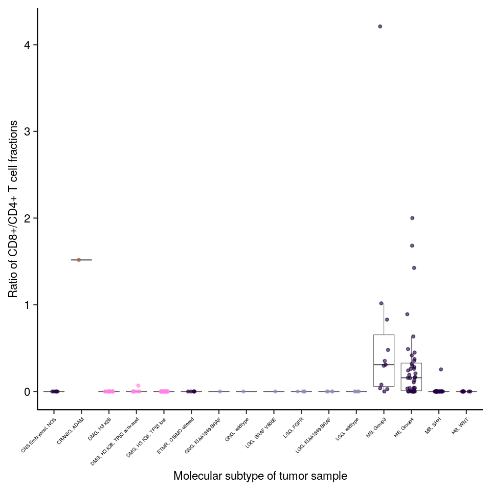

```r
# subset for just cd8/cd4 ratio
ratio_df <- quantiseq_subset %>%
  filter(cell_type == "cd8_cd4_ratio",
         cancer_group != "Other",
         !is.nan(score),
         !is.infinite(score)
         )

# distributions of PDL1 expression
ratio_plot <- ggplot(ratio_df) +
  aes(x = molecular_subtype,
      y = score) +
  # remove outliers
  geom_boxplot(outlier.shape = NA, color = "grey40", size = 0.2) +
  geom_jitter(width = 0.15, size = 0.75, alpha = 0.6,  aes(color = broad_histology_hex)) +
  scale_color_identity() +
  labs(x = "Molecular subtype of tumor sample",
       y = "Ratio of CD8+/CD4+ T cell fractions") +
  ggpubr::theme_pubr() +
  theme(axis.text.x = element_text(hjust = 1,
                                   size = rel(0.3),
                                   angle = 45),
        axis.text.y = element_text(size = rel(0.7)),
        axis.title = element_text(size = rel(0.7)),
        axis.line = element_line(size = rel(0.7)),
        axis.ticks = element_line(size = rel(0.7)))

ratio_plot
```

```r
ggsave(cd8_cd4_ratio_plot_file, ratio_plot, width = 2.75, height = 4, useDingbats = FALSE)
```